# Project 2: Data Mining, Classification, Prediction

SDS322E

# Mining, Classification, Prediction

## Sapna Bhakta sab5574

### Introduction

I chose to use the Salaries dataset that is within the carData library. It contains 397 observations and 6 variables. The rank is a factor with levels AssocProf, AsstProf, and Prof. The discipline is a factor with levels A(“theoretical” departments) or B(“applied” departments). There are three numerical variables, the yrs.since.phd (years since phD), yrs.service (years of service) and salary. The last variable is sex with levels Female and Male and is used as our binary variable. There are 358 males, 39 females, 181 in discipline A and 216 in discipline B. I found this dataset interesting because I was curious if the numerical variables would be related to a professor’s gender.

```r
library(tidyverse)
library(carData)
library(GGally)
df <- Salaries
nrow(df)
```

```
## [1] 397
```

```r
length(which(df$sex == "Male"))
```

```
## [1] 358
```

```r
length(which(df$sex == "Female"))
```

```
## [1] 39
```

```r
length(which(df$discipline == "A"))
```

```
## [1] 181
```

```r
length(which(df$discipline == "B"))
```

```
## [1] 216
```

### Cluster Analysis

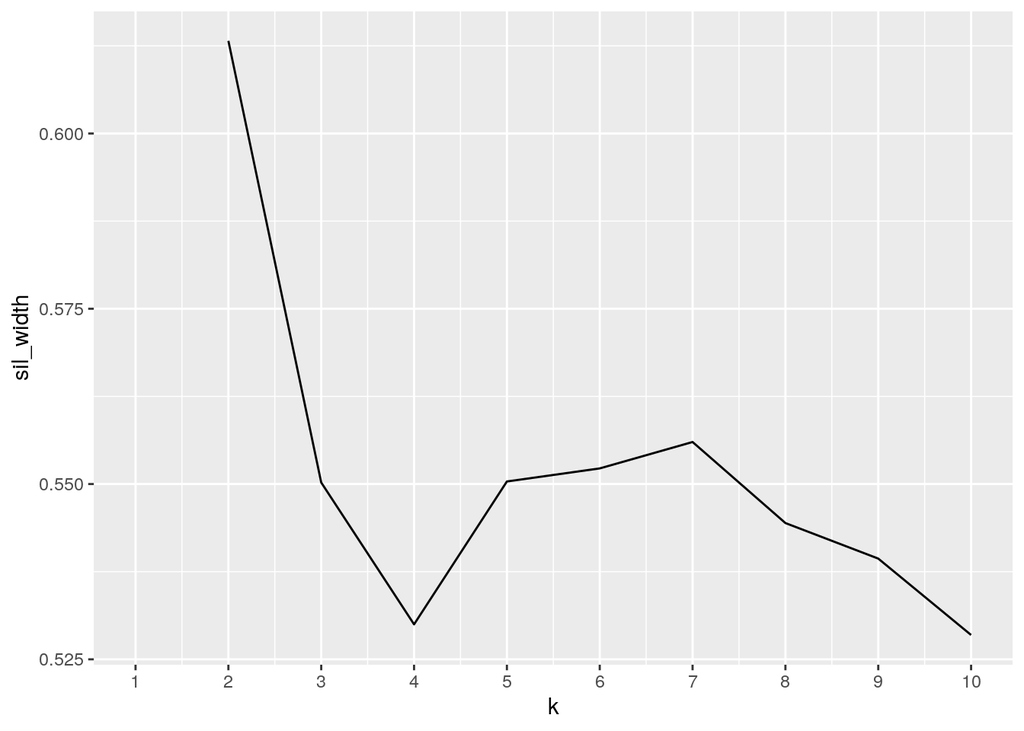

```r
library(cluster)
pam_dat <- df %>% select(yrs.since.phd, yrs.service, salary)
sil_width <- vector()
for (i in 2:10) {
    pam_fit <- pam(pam_dat, k = i)
    sil_width[i] <- pam_fit$silinfo$avg.width
}
ggplot() + geom_line(aes(x = 1:10, y = sil_width)) + scale_x_continuous(name = "k",
    breaks = 1:10)
```

```r
pam1 <- df %>% pam(k = 2)
pam1
```

```
## Medoids:
##       ID rank discipline yrs.since.phd yrs.service sex salary
## [1,] 350    3          2            27          28   2 144309
## [2,] 240    3          1            19           6   2  96200
## Clustering vector:
##   [1] 1 1 2 2 1 2 1 1 2 1 2 2 2 2 2 2 2 2 1 1 2 2 2 2 2 2 1 2 2 2 1 2 2 2 2 2 1
##  [38] 2 1 2 1 2 2 1 2 2 2 1 1 2 1 2 2 2 2 2 2 2 2 2 2 2 2 2 2 2 2 2 2 2 1 1 2 2
##  [75] 2 2 1 1 2 2 1 1 1 2 1 1 1 2 1 2 2 2 2 1 1 2 2 1 2 2
##  [ reached getOption("max.print") -- omitted 297 entries ]
## Objective function:
##    build     swap
## 14966.14 13533.83
##
## Available components:
##  [1] "medoids"    "id.med"     "clustering" "objective"  "isolation"
##  [6] "clusinfo"   "silinfo"    "diss"       "call"       "data"
```

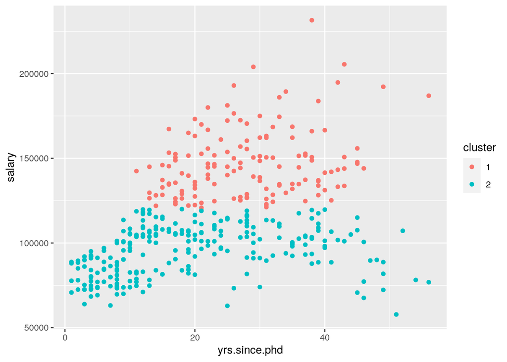

```r
pamclust <- df %>% mutate(cluster = as.factor(pam1$clustering))
pamclust <- pamclust[, c(1, 2, 3, 4, 6, 5, 7)]
pamclust %>% ggplot(aes(yrs.since.phd, salary, color = cluster)) +
    geom_point()
```

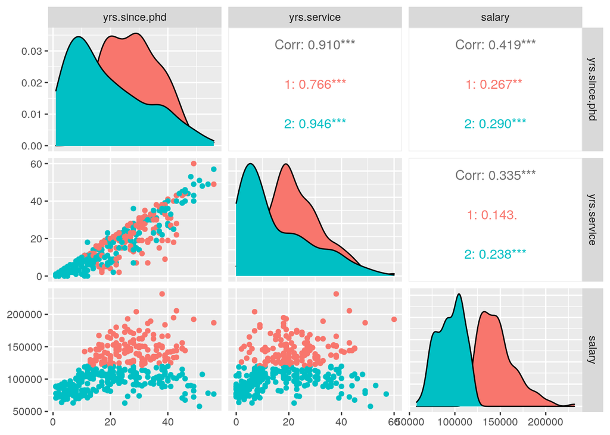

```r
ggpairs(pamclust, columns = 3:5, aes(color = cluster))
```

```r
pam1$silinfo$avg.width
```

```
## [1] 0.6132129
```

### Dimensionality Reduction with PCA

```r
df_nums <- df %>% select_if(is.numeric) %>% scale
pca <- princomp(df_nums)
summary(pca, loadings = T)
```

```
## Importance of components:
##                          Comp.1    Comp.2     Comp.3
## Standard deviation     1.466454 0.8697855 0.29228401
## Proportion of Variance 0.718639 0.2528124 0.02854856
## Cumulative Proportion  0.718639 0.9714514 1.00000000
##
## Loadings:
##               Comp.1 Comp.2 Comp.3
## yrs.since.phd  0.650  0.239  0.721
## yrs.service    0.633  0.353 -0.689
## salary         0.419 -0.904
```

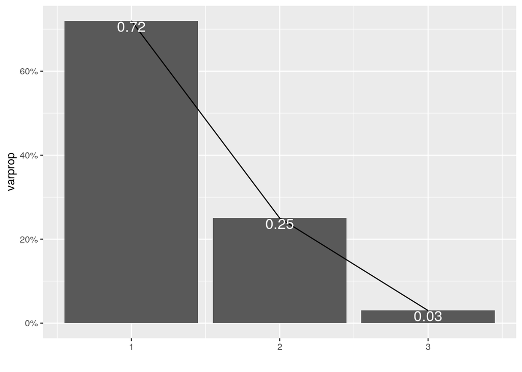

```r
eigval <- pca$sdev^2  #square to convert SDs to eigenvalues
varprop = round(eigval/sum(eigval), 2)  #proportion of var explained by each PC

ggplot() + geom_bar(aes(y = varprop, x = 1:3), stat = "identity") +
    xlab("") + geom_path(aes(y = varprop, x = 1:3)) + geom_text(aes(x = 1:3,
    y = varprop, label = round(varprop, 2)), vjust = 1, col = "white",
    size = 5) + scale_y_continuous(breaks = seq(0, 0.6, 0.2),
    labels = scales::percent) + scale_x_continuous(breaks = 1:10)
```

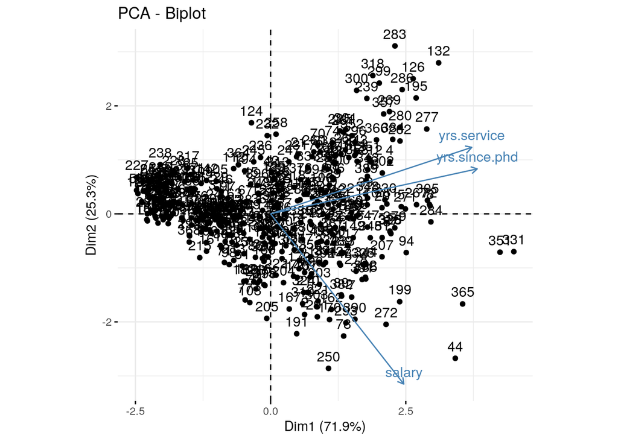

```r
library(factoextra)
fviz_pca_biplot(pca) + coord_fixed()
```

If we look at the eigenvalues, only PCA1 has a value greater than 1. If we look at the graph the cumulative proportion of variances is greather than 80% if we keep PCA1 and PCA2. The graph also indicates a bend after PCA2, therefor I would choose to keep the first two PCA’s.

From the loadings, we can analyze the data. PC1 indicates general strength with all values being positive and semi-close together (salary is a little lower). Since years since phd and years service are higher they are stronger. PC2 is a years since phd and years service versus salary. Higher scores on PC2 mean a lower salary and low scores on PC2 mean a higher salary. If we were to interpret PC3 it would be years since phd versus years service. A high score indicating a higher years since phd and a lower years service and vise versa for a low score. We can additionally see the relationships on the graph above.

### Linear Classifier

```r
class_diag <- function(score, truth, positive, cutoff = 0.5,
    strictlygreater = T) {
    if (strictlygreater == T)
        pred <- factor(score > cutoff, levels = c("TRUE", "FALSE")) else pred <- factor(score >= cutoff, levels = c("TRUE", "FALSE"))
    truth <- factor(truth == positive, levels = c("TRUE", "FALSE"))
    tab <- table(truth, pred)
    acc = sum(diag(tab))/sum(tab)
    sens = tab[1, 1]/rowSums(tab)[1]
    spec = tab[2, 2]/rowSums(tab)[2]
    ppv = tab[1, 1]/colSums(tab)[1]
    # CALCULATE F1
    f1 = 2 * (sens * ppv)/(sens + ppv)
    # CALCULATE EXACT AUC
    truth <- as.numeric(truth == "TRUE")
    ord <- order(score, decreasing = TRUE)
    score <- score[ord]
    truth <- truth[ord]
    TPR = cumsum(truth)/max(1, sum(truth))
    FPR = cumsum(!truth)/max(1, sum(!truth))
    dup <- c(score[-1] >= score[-length(score)], FALSE)
    TPR <- c(0, TPR[!dup], 1)
    FPR <- c(0, FPR[!dup], 1)
    n <- length(TPR)
    auc <- sum(((TPR[-1] + TPR[-n])/2) * (FPR[-1] - FPR[-n]))
    round(data.frame(acc, sens, spec, ppv, f1, ba = (sens + spec)/2,
        auc, row.names = "Metrics"), 4)
}
```

```r
# model for discipline
fit <- glm(discipline ~ yrs.since.phd + yrs.service + salary,
    data = df, family = "binomial")
probs_glm <- predict(fit, type = "response")
class_diag(probs_glm, df$discipline, positive = "A")
```

```
##            acc   sens   spec    ppv     f1     ba    auc
## Metrics 0.3577 0.5028 0.2361 0.3555 0.4165 0.3694 0.2707
```

```r
# model for sex
fit <- glm(sex ~ yrs.since.phd + yrs.service + salary, data = df,
    family = "binomial")
probs_glm <- predict(fit, type = "response")
class_diag(probs_glm, df$sex, positive = "Male")
```

```
##            acc sens spec    ppv     f1  ba    auc
## Metrics 0.9018    1    0 0.9018 0.9483 0.5 0.6747
```

```r
# I am going to use the model for sex for the next steps.
```

```r
df$probs_glm <- probs_glm
library(caret)
mean(probs_glm)
```

```
## [1] 0.9017632
```

```r
y <- df$sex
y <- factor(y, levels = c("Male", "Female"))
x <- df$probs_glm
yhat <- ifelse(x > 0.9017632, "Male", "Female")
yhat <- factor(yhat, levels = c("Male", "Female"))
table(actual = y, predicted = yhat) %>% addmargins
```

```
##         predicted
## actual   Male Female Sum
##   Male    215    143 358
##   Female   12     27  39
##   Sum     227    170 397
```

```r
set.seed(322)
k = 10

data <- sample_frac(df)  #randomly order rows
folds <- rep(1:k, length.out = nrow(data))  #create folds

diags <- NULL

i = 1
for (i in 1:k) {
    # create training and test sets
    train <- data[folds != i, ]
    test <- data[folds == i, ]
    truth <- test$sex

    # train model
    fit <- glm(sex ~ yrs.since.phd + yrs.service + salary, data = df,
        family = "binomial")

    # test model
    probs <- predict(fit, newdata = test, type = "response")

    # get performance metrics for each fold
    diags <- rbind(diags, class_diag(probs, truth, positive = "Male"))
}

# average performance metrics across all folds
summarize_all(diags, mean)
```

```
##       acc sens spec     ppv      f1  ba     auc
## 1 0.90173    1    0 0.90173 0.94754 0.5 0.67897
```

I used logistic regression for my linear classifier. When taking the mean of the probabilities, a value of .90176 is produced. Therefor, it is used as the cutoff when creating the confusion matrix in order to maximize accuracy. The first AUC value is .6747 which is a pretty poor model. After performing the cross validation the AUC slightly increases to .67897 which is still a poor model but does not show signs of overfitting and it is improving which is a good thing.

### Non-Parametric Classifier

```r
library(caret)
knn_fit <- knn3(sex ~ yrs.since.phd + yrs.service + salary, data = df)

probs_knn <- predict(knn_fit, df)
class_diag(probs_knn[, 2], df$sex, positive = "Male")
```

```
##            acc   sens   spec    ppv     f1     ba    auc
## Metrics 0.9043 0.9944 0.0769 0.9082 0.9493 0.5357 0.8807
```

```r
mean(probs_knn[, 2])
```

```
## [1] 0.9030027
```

```r
yhat <- ifelse(probs_knn[, 2] > 0.9030027, "Male", "Female")
yhat <- factor(yhat, levels = c("Male", "Female"))
table(actual = y, predicted = yhat) %>% addmargins
```

```
##         predicted
## actual   Male Female Sum
##   Male    245    113 358
##   Female    0     39  39
##   Sum     245    152 397
```

```r
k = 10

data <- sample_frac(df)  #randomly order rows
folds <- rep(1:k, length.out = nrow(df))  #create folds

diags <- NULL

i = 1
for (i in 1:k) {
    # create training and test sets
    train <- data[folds != i, ]
    test <- data[folds == i, ]
    truth <- test$sex

    # train model
    fit <- knn3(sex ~ yrs.since.phd + yrs.service + salary, data = df)

    # test model
    probs <- predict(fit, newdata = test)[, 2]

    # get performance metrics for each fold
    diags <- rbind(diags, class_diag(probs, truth, positive = "Male"))
}

# average performance metrics across all folds
summarize_all(diags, mean)
```

```
##       acc    sens spec     ppv      f1      ba     auc
## 1 0.90405 0.99436 0.07 0.90816 0.94878 0.53218 0.88383
```

### Regression/Numeric Prediction

```r
fit <- lm(yrs.since.phd ~ salary + yrs.service, data = df)
yhat <- predict(fit)
mean((df$yrs.since.phd - yhat)^2)
```

```
## [1] 26.12637
```

```r
k = 5  #choose number of folds
data <- df[sample(nrow(df)), ]  #randomly order rows
folds <- cut(seq(1:nrow(df)), breaks = k, labels = F)  #create folds
diags <- NULL
for (i in 1:k) {
    train <- data[folds != i, ]
    test <- data[folds == i, ]
    ## Fit linear regression model to training set
    fit <- lm(yrs.since.phd ~ salary + yrs.service, data = df)
    ## Get predictions/y-hats on test set (fold i)
    yhat <- predict(fit, newdata = test)
    ## Compute prediction error (MSE) for fold i
    diags <- mean((df$yrs.since.phd - yhat)^2)
}
mean(diags)  ## get average MSE across all folds (much higher error)!
```

```
## [1] 316.1535
```

### Python

```python
data = r.df
```

```r
library(reticulate)
use_python("/usr/bin/python3")
plot <- import("matplotlib")
plot$use("Agg", force = TRUE)

np <- import("numpy")
pd <- import("pandas")
plt <- import("matplotlib.pyplot")
head(py$data$rank)
```

```
## [1] Prof      Prof      AsstProf  Prof      Prof      AssocProf
## Levels: AsstProf AssocProf Prof
```

```python
import numpy as np
import pandas as pd
import matplotlib.pyplot as plt
```

```python
data.head()
```

```
##        rank discipline  yrs.since.phd    ...       sex  salary  probs_glm
## 0      Prof          B             19    ...      Male  139750   0.944141
## 1      Prof          B             20    ...      Male  173200   0.959649
## 2  AsstProf          B              4    ...      Male   79750   0.818000
## 3      Prof          B             45    ...      Male  115000   0.957525
## 4      Prof          B             40    ...      Male  141500   0.974851
##
## [5 rows x 7 columns]
```

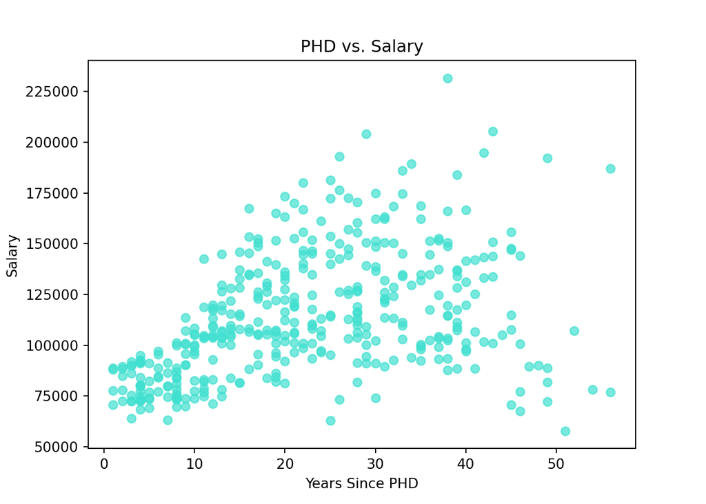

```python
plt.scatter(data["yrs.since.phd"], data["salary"], color="turquoise", alpha=.7)
plt.xlabel('Years Since PHD')
plt.ylabel('Salary')
plt.title('PHD vs. Salary')
r.plt.show()
```

I used the r. and py$ functions in order to preview the data. First I see the ranks that are part of the dataset and then I just did a preview of the first five rows. Then I created a plot that has years since phd on the x axis and salary on the y axis. It seems to be scattered throughout with a concentration in the bottom left corner (less years since a phd related to a lower salary).

### Concluding Remarks

Overall, this dataset was intersting because it shows us some of the relationships between salary, years since phd, years of service, and other variables defining professors. I found the cluster analysis to be interesting since it appears by eye that there is only one real cluster and the rest of the points are quite dispersed which could mean it would be better to analyze further into the specific teachings of each professor (analyzing the discipline variable more specifically, maybe with more data). Overall, I enjoyed working with the dataset and think there is a lot more on the models that could be improved.